# Final Practicum II

Kanishka Parganiha

11/16/2020

**2** **Importing Data**

**create a data model in the form of an ERD in Crow’s Foot notation using a tool of your choice (e.g., LucidChart, TOAD, MySQL Workbench, etc.) and embed an image of the model in your notebook. Your ERD should be a normalized model and not a direct representation of the data in the files. Later, when you load the data you will map the data from the files to the columns in the tables.**

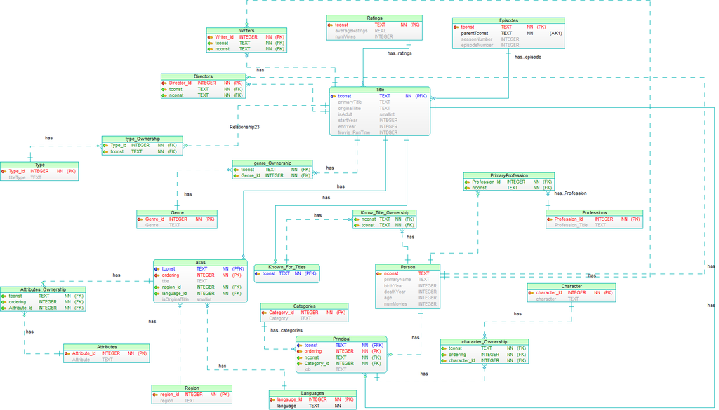

ERD Diagram Design in MySql WorkBench

**title.principals**

```r
title.principals<-read.csv(file="F:/IE Courses/Database Management Systems/Assignments/Practicum 2/Test/title.principals.tsv/data.tsv",sep='\t',header=TRUE,na = c("\\N"))
head(title.principals)
```

```
##      tconst ordering    nconst        category                     job
## 1 tt0000001        1 nm1588970            self                    <NA>
## 2 tt0000001        2 nm0005690        director                    <NA>
## 3 tt0000001        3 nm0374658 cinematographer director of photography
## 4 tt0000002        1 nm0721526        director                    <NA>
## 5 tt0000002        2 nm1335271        composer                    <NA>
## 6 tt0000003        1 nm0721526        director                    <NA>
##   characters
## 1   ["Self"]
## 2       <NA>
## 3       <NA>
## 4       <NA>
## 5       <NA>
## 6       <NA>
```

**name.basics**

```r
#library(tidyr)
name.basics<-read.csv(file="F:/IE Courses/Database Management Systems/Assignments/Practicum 2/Test/name.basics.tsv/data.tsv",na =c("\\N"),sep='\t',header=TRUE)
head(name.basics)
```

```
##      nconst     primaryName birthYear deathYear
## 1 nm0000001    Fred Astaire      1899      1987
## 2 nm0000002   Lauren Bacall      1924      2014
## 3 nm0000003 Brigitte Bardot      1934        NA
## 4 nm0000004    John Belushi      1949      1982
## 5 nm0000005  Ingmar Bergman      1918      2007
## 6 nm0000006  Ingrid Bergman      1915      1982
##                     primaryProfession                          knownForTitles
## 1      soundtrack,actor,miscellaneous tt0072308,tt0031983,tt0050419,tt0053137
## 2                  actress,soundtrack tt0071877,tt0037382,tt0038355,tt0117057
## 3 actress,soundtrack,music_department tt0049189,tt0054452,tt0059956,tt0057345
## 4             actor,soundtrack,writer tt0077975,tt0078723,tt0072562,tt0080455
## 5               writer,director,actor tt0050986,tt0050976,tt0060827,tt0083922
## 6         actress,soundtrack,producer tt0038787,tt0038109,tt0036855,tt0034583
```

**title.akas**

```r
title.akas<-read.csv(file="F:/IE Courses/Database Management Systems/Assignments/Practicum 2/Test/title.akas.tsv/data.tsv",na =c("\\N"),sep='\t',header=TRUE)
head(title.akas)
```

```
##     titleId ordering                     title region language       types
## 1 tt0000001        1                ??????????     UA     <NA> imdbDisplay
## 2 tt0000001        2                Carmencita     DE     <NA>        <NA>
## 3 tt0000001        3 Carmencita - spanyol tánc     HU     <NA> imdbDisplay
## 4 tt0000001        4                ??????????     GR     <NA> imdbDisplay
## 5 tt0000001        5                ??????????     RU     <NA> imdbDisplay
## 6 tt0000001        6                Carmencita     US     <NA>        <NA>
##      attributes isOriginalTitle
## 1          <NA>               0
## 2 literal title               0
## 3          <NA>               0
## 4          <NA>               0
## 5          <NA>               0
## 6          <NA>               0
```

**title.basics**

```r
title.basics<-read.csv(file="F:/IE Courses/Database Management Systems/Assignments/Practicum 2/Test/title.basics.tsv/data.tsv",na =c("\\N"),sep='\t',header=TRUE)
head(title.basics)
```

```
##      tconst titleType           primaryTitle          originalTitle isAdult
## 1 tt0000001     short             Carmencita             Carmencita       0
## 2 tt0000002     short Le clown et ses chiens Le clown et ses chiens       0
## 3 tt0000003     short         Pauvre Pierrot         Pauvre Pierrot       0
## 4 tt0000004     short            Un bon bock            Un bon bock       0
## 5 tt0000005     short       Blacksmith Scene       Blacksmith Scene       0
## 6 tt0000006     short      Chinese Opium Den      Chinese Opium Den       0
##   startYear endYear runtimeMinutes                   genres
## 1      1894      NA              1        Documentary,Short
## 2      1892      NA              5          Animation,Short
## 3      1892      NA              4 Animation,Comedy,Romance
## 4      1892      NA             12          Animation,Short
## 5      1893      NA              1             Comedy,Short
## 6      1894      NA              1                    Short
```

**title.crew**

```r
title.crew<-read.csv(file="F:/IE Courses/Database Management Systems/Assignments/Practicum 2/Test/title.crew.tsv/data.tsv",na =c("\\N"),sep='\t',header=TRUE)
head(title.crew)
```

```
##      tconst directors writers
## 1 tt0000001 nm0005690    <NA>
## 2 tt0000002 nm0721526    <NA>
## 3 tt0000003 nm0721526    <NA>
## 4 tt0000004 nm0721526    <NA>
## 5 tt0000005 nm0005690    <NA>
## 6 tt0000006 nm0005690    <NA>
```

**title.episode**

[output not shown]

**title.ratings**

```r
title.ratings<-read.csv(file="F:/IE Courses/Database Management Systems/Assignments/Practicum 2/Test/title.ratings.tsv/data.tsv",sep='\t',header=TRUE,na =c("\\N"))
head(title.ratings)
```

```
##      tconst averageRating numVotes
## 1 tt0000001           5.6     1656
## 2 tt0000002           6.1      201
## 3 tt0000003           6.5     1368
## 4 tt0000004           6.2      122
## 5 tt0000005           6.2     2151
## 6 tt0000006           5.3      115
```

**Setup SQLIte**

```r
library(RSQLite)
con <- dbConnect(RSQLite::SQLite(), "IMDB.db")

dbListTables(con)
```

```
##  [1] "Actor"                "Attribute"            "Attribute_Ownership"
##  [4] "Attributes"           "Attributes_Ownership" "Categories"
##  [7] "Character"            "Directors"            "Episode"
## [10] "Episodes"             "Genre"                "Know_For_Titles"
## [13] "Know_Title_Ownership" "Known_For_Titles"     "Languages"
## [16] "Person"               "PrimaryProfession"    "Principal"
## [19] "Professions"          "Ratings"              "Region"
## [22] "Title"                "Type"                 "Writers"
## [25] "akas"                 "character_Ownership"  "genre_Ownership"
## [28] "type_Ownership"
```

```r
# Disconnect from the database
# dbDisconnect(con)
```

**3**

**5. After loading the data, execute UPDATE statements for the two newly created columns in (2C). You may interpret what appearing in movies means and what you classify as movies – just make it clear in your notebook.**

```r
dbExecute(con,"BEGIN TRANSACTION;")
```

```
## [1] 0
```

```r
dbExecute(con,"UPDATE Person SET age=(select strftime('%Y','now'))-birthYear where deathYear in (select deathYear from Person where deathYear is  0)")
```

```
## [1] 410
```

```r
dbExecute(con,"UPDATE Person SET age=deathYear-birthYear where deathYear in (select deathYear from Person where deathYear is not 0)")
```

```
## [1] 140
```

```r
dbExecute(con,"UPDATE Person SET numMovies=(select count(*) from Person Pr inner join PrimaryProfession PP on Pr.nconst=PP.nconst inner join Professions Pf on PP.Profession_Id=Pf.Profession_Id inner join Know_Title_Ownership K on K.nconst=Pr.nconst  where Pf.Profession_Title = 'actor' or Pf.Profession_Title = 'actress' group by K.nconst)")
```

```
## [1] 550
```

```r
dbExecute(con,"COMMIT;")
```

```
## [1] 0
```

**6. Add triggers to the appropriate tables so that the newly created columns in (2C) are automatically updated when new data in inserted.**

```r
dbExecute(con,"drop trigger if exists Age")
```

```
## [1] 0
```

```r
dbExecute(con,"drop trigger if exists numMovies")
```

```
## [1] 0
```

```r
dbExecute(con,"CREATE TRIGGER Age after insert  on  Person
 BEGIN
update  Person  set age = (deathYear-birthYear) where nconst=new.nconst and deathYear!=0 ;
update  Person  set age = (select strftime('%Y','now')-birthYear) where nconst=new.nconst and deathYear=0;
END;")
```

```
## [1] 0
```

```r
dbExecute(con,"CREATE TRIGGER numMovies after insert on Know_Title_Ownership
 BEGIN
update  Person  set numMovies = (select numMovies from Person where nconst=new.nconst) + (select count(distinct(new.tconst)) from Know_Title_Ownership group by nconst) where nconst=new.nconst;
END;")
```

```
## [1] 0
```

```r
## Update Statement
dbExecute(con,"BEGIN TRANSACTION;")
```

```
## [1] 0
```

```r
dbExecute(con,"INSERT INTO Person  VALUES('nm9999991','Kanishka Parganiha',1954,2013,0,0);")
```

```
## [1] 2
```

```r
dbExecute(con,"INSERT INTO Person  VALUES('nm9999992','Him Sampat',1984,0,0,0);")
```

```
## [1] 2
```

```r
dbExecute(con,"INSERT INTO Know_Title_Ownership  VALUES('nm9999992','tt0299658');")
```

```
## [1] 2
```

```r
dbExecute(con,"INSERT INTO Know_Title_Ownership  VALUES('nm9999991','tt9999999');")
```

```
## [1] 2
```

```r
dbExecute(con,"INSERT INTO Know_Title_Ownership  VALUES('nm9999992','tt0299699');")
```

```
## [1] 2
```

```r
dbExecute(con,"INSERT INTO Know_Title_Ownership  VALUES('nm9999991','tt4999999');")
```

```
## [1] 2
```

```r
dbExecute(con,"INSERT INTO Know_Title_Ownership  VALUES('nm9999991','tt5999999');")
```

```
## [1] 2
```

```r
dbExecute(con,"COMMIT;")
```

```
## [1] 0
```

```r
dbGetQuery(con,"select * from Person where nconst > 'nm0000550'  ")
```

```
##      nconst        primaryName birthYear deathYear age numMovies
## 1 nm0000551    Dermot Mulroney      1963         0  57         4
## 2 nm0000552       Eddie Murphy      1961         0  59         4
## 3 nm9999991 Kanishka Parganiha      1954      2013  59         3
## 4 nm9999992         Him Sampat      1984         0  36         2
```

```r
dbGetQuery(con,"select * from Know_Title_Ownership where nconst > 'nm0000550'  ")
```

```
##       nconst    tconst
## 1  nm0000551 tt0372532
## 2  nm0000551 tt0119738
## 3  nm0000551 tt0096487
## 4  nm0000551 tt1322269
## 5  nm0000552 tt0443489
## 6  nm0000552 tt0094898
## 7  nm0000552 tt0097481
## 8  nm0000552 tt0117218
## 9  nm9999992 tt0299658
## 10 nm9999991 tt9999999
## 11 nm9999992 tt0299699
## 12 nm9999991 tt4999999
## 13 nm9999991 tt5999999
```

**7. Create a view that lists the name of each actor or actress, their age, whether they are dead or not, and how many movies they are known for based on what is stored for each actor or actress. If you work with a data sample it does not matter if the movie is actually in the database.**

```r
dbExecute(con,"drop view if exists Actor;")
```

```
## [1] 0
```

```r
dbExecute(con,"CREATE VIEW Actor as select Pr.nconst,Pr.primaryName,Pf.Profession_Title,Pr.age,Pr.numMovies from Person Pr inner join PrimaryProfession PP on Pr.nconst=PP.nconst inner join Professions Pf on PP.Profession_Id=Pf.Profession_Id inner join Know_Title_Ownership K on K.nconst=Pr.nconst  where Pf.Profession_Title = 'actor' or Pf.Profession_Title = 'actress' group by K.nconst")
```

```
## [1] 0
```

```r
dbGetQuery(con,'select * from Actor limit 5')
```

```
##      nconst     primaryName Profession_Title age numMovies
## 1 nm0000001    Fred Astaire            actor  88         4
## 2 nm0000002   Lauren Bacall          actress  90         4
## 3 nm0000003 Brigitte Bardot          actress  86         4
## 4 nm0000004    John Belushi            actor  33         4
## 5 nm0000005  Ingmar Bergman            actor  89         4
```

```r
SeasonCountNew<-dbGetQuery(con,"select T.primaryTitle,count(distinct(E.seasonNumber)) as TotalSeason  from Episodes E inner join Title T on E.parentTconst=T.tconst group by E.parentTconst")

head(SeasonCountNew)
```

```
## [1] primaryTitle TotalSeason
## <0 rows> (or 0-length row.names)
```

```r
library(ggplot2)
#ggplot(SeasonCountNew[1:50,], aes(x=reorder(primaryTitle,-TotalSeason), y=TotalSeason,fill = primaryTitle))+ geom_bar(stat = "identity")+theme(axis.text.x = element_text(angle = 90, hjust =1,vjust = 0.5))+geom_text(aes(label = TotalSeason),angle = 0, hjust=0.6,vjust=-0.5)+theme(legend.position = "none")
```

**9. Build a function in your code or a stored procedure in the database (approach is your choice) called addActor() that adds a new actor to the database: this requires updating several tables, so the insertions must occur within a transaction in order to function properly in a concurrent environment. Test your function by inserting a new actor – you may make up a name and associated information. Show evidence in your notebook that the actor was properly inserted.**

```r
newnconst <- "nm9999993"
newprimaryName <- "Nandan Chaudhari"
newbirthYear <- as.integer(1993)
newdeathYear <- as.integer(0)
Id<-c("'tt0443489'","'tt044348d'" ,"'tt0443486'")

options(useFancyQuotes = FALSE)


 addActor<-function(newnconst,newprimaryName,newbirthYear,newdeathYear,Id)
   {

   dbExecute(con,"BEGIN TRANSACTION;")
   dbExecute(con,paste("INSERT INTO Person VALUES(",sQuote(newnconst),",",sQuote(newprimaryName),",",newbirthYear,",",
                            newdeathYear,",","0",",","0",");",sep=''))
   for(i in Id){dbExecute(con,paste("INSERT INTO  Know_Title_Ownership VALUES(",sQuote(newnconst),",",i,");"))}
   dbExecute(con,paste("INSERT INTO PrimaryProfession VALUES(",sQuote(newnconst),",",' 1',");"))
   dbExecute(con,"COMMIT;")

   }


#dbExecute(con,"rollback;")

addActor(newnconst,newprimaryName,newbirthYear,newdeathYear,Id)
```

```
## [1] 0
```

```r
dbGetQuery(con,"select * from Person where nconst > 'nm0000550'  ")
```

```
##      nconst        primaryName birthYear deathYear age numMovies
## 1 nm0000551    Dermot Mulroney      1963         0  57         4
## 2 nm0000552       Eddie Murphy      1961         0  59         4
## 3 nm9999991 Kanishka Parganiha      1954      2013  59         3
## 4 nm9999992         Him Sampat      1984         0  36         2
## 5 nm9999993   Nandan Chaudhari      1993         0  27         3
```

```r
dbGetQuery(con,"select * from Know_Title_Ownership where nconst > 'nm0000550'  ")
```

```
##       nconst    tconst
## 1  nm0000551 tt0372532
## 2  nm0000551 tt0119738
## 3  nm0000551 tt0096487
## 4  nm0000551 tt1322269
## 5  nm0000552 tt0443489
## 6  nm0000552 tt0094898
## 7  nm0000552 tt0097481
## 8  nm0000552 tt0117218
## 9  nm9999992 tt0299658
## 10 nm9999991 tt9999999
## 11 nm9999992 tt0299699
## 12 nm9999991 tt4999999
## 13 nm9999991 tt5999999
## 14 nm9999993 tt0443489
## 15 nm9999993 tt044348d
## 16 nm9999993 tt0443486
```

**10. Build a function in your code or a stored procedure in the database (approach is your choice) called deleteActor() that removes an actor from the database: this requires updating several tables, so the deletions must occur within a transaction in order to function properly in a concurrent environment. Test your function by deleting a new actor inserted in (9) – show evidence that the removal was successful.**

```r
 deleteActor<-function(newnconst)
   {

   dbExecute(con,"BEGIN TRANSACTION;")
   dbExecute(con,paste("DELETE FROM Person where nconst=",sQuote(newnconst),sep=''))
   dbExecute(con,paste("DELETE FROM Know_Title_Ownership where nconst=",sQuote(newnconst),sep=''))
   dbExecute(con,paste("DELETE FROM PrimaryProfession where nconst=",sQuote(newnconst),sep=''))
   dbExecute(con,"COMMIT;")

   }

deleteActor('nm9999993')
```

```
## [1] 0
```

```r
deleteActor('nm9999991')
```

```
## [1] 0
```

```r
deleteActor('nm9999992')
```

```
## [1] 0
```

```r
dbGetQuery(con,"select * from Person where nconst > 'nm0000550'  ")
```

```
##      nconst     primaryName birthYear deathYear age numMovies
## 1 nm0000551 Dermot Mulroney      1963         0  57         4
## 2 nm0000552    Eddie Murphy      1961         0  59         4
```

```r
dbGetQuery(con,"select * from Know_Title_Ownership where nconst > 'nm0000550'  ")
```

```
##      nconst    tconst
## 1 nm0000551 tt0372532
## 2 nm0000551 tt0119738
## 3 nm0000551 tt0096487
## 4 nm0000551 tt1322269
## 5 nm0000552 tt0443489
## 6 nm0000552 tt0094898
## 7 nm0000552 tt0097481
## 8 nm0000552 tt0117218
```

**11.Write a query to retrieve the names and ages of all actors who appeared in more than two movies (but not TV Movies) which an above average rating. Show the results of the query in your notebook. Do not hard code the average rating. If you did not load the title.principals.tsv file then you can use the knownFor field in the names.basic.tsv file – or the provided samples.**

```r
dbGetQuery(con,"select distinct Pr.primaryName,Pr.age,Pr.numMovies from Person Pr
                 inner join PrimaryProfession PP on Pr.nconst=PP.nconst
                 inner join Professions Pf on PP.Profession_Id=Pf.Profession_Id
                 inner join Know_Title_Ownership K on K.nconst=Pr.nconst
                    where Pf.Profession_Title = 'actor' or Pf.Profession_Title = 'actress' and Pr.numMovies>2
                        and  K.tconst in (select tconst from Ratings  where averageRatings > (select avg(averageRatings) from Ratings))
                            and tconst in (select O.tconst from Type T inner join type_Ownership O on T.Type_Id=O.Type_Id where T.titleType='movie' )limit 5")
```

```
##       primaryName age numMovies
## 1    Fred Astaire  88         4
## 2    John Belushi  33         4
## 3  Ingmar Bergman  89         4
## 4 Humphrey Bogart  58         4
## 5   Marlon Brando  80         4
```

**12. Write a query that finds an actor by name (pick a name). Measure the execution time of the query. Then create an index that would improve the performance of the query and then run and measure it again. Show the difference in a bar chart and comment on why that’s the case.**

```r
dbExecute(con,"DROP index if exists NEW_INDEX")
```

```
## [1] 0
```

```r
start_time_1 <- Sys.time()

dbGetQuery(con,"select * from Person where nconst='nm0000551' ")
```

```
##      nconst     primaryName birthYear deathYear age numMovies
## 1 nm0000551 Dermot Mulroney      1963         0  57         4
```

```r
end_time_1 <- Sys.time()

p<-round(difftime(end_time_1, start_time_1, units = "sec"),2)



##Creating Index
dbExecute(con,"CREATE INDEX NEW_INDEX ON Person(LENGTH(nconst)); ")
```

```
## [1] 0
```

```r
start_time_2 <- Sys.time()

dbGetQuery(con,"select * from Person where nconst='nm0000551' ")
```

```
##      nconst     primaryName birthYear deathYear age numMovies
## 1 nm0000551 Dermot Mulroney      1963         0  57         4
```

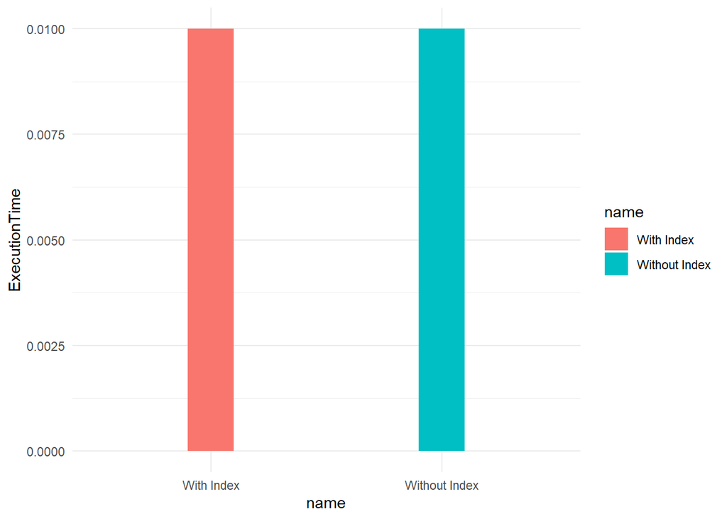

```r
end_time_2 <- Sys.time()

q<-round(difftime(end_time_2, start_time_2, units = "sec"),2)



##Display
library(ggplot2)
data <- data.frame(
    name=c("Without Index","With Index") ,
    ExecutionTime=c(p,q)
)


# Barplot

ggplot(data, aes(x=name, y=ExecutionTime,fill=name)) +
    geom_bar(stat = "identity", width=0.2) +theme_minimal()
```

```r
#To delete a row
#dbExecute(con,"DROP index NEW_INDEX") ;
```

**13. Add several indexes to a table of your choice (one containing lots of rows) and then insert additional rows into the table. Provide measurements of insert performance with no additional index, one, two, three, etc. Plot the performance change in a line graph and comment on the difference.**

```r
dbExecute(con,"CREATE INDEX NEWINDEX ON Episodes(LENGTH(tconst)); ")
```

```
## [1] 0
```

```r
start_time_1 <- Sys.time()


dbExecute(con,"INSERT INTO Episodes  VALUES('tt1111111','tt0048844',1,1); ")
```

```
## [1] 1
```

```r
end_time_1 <- Sys.time()

p1<-round(difftime(end_time_1, start_time_1, units = "sec"),2)

start_time_1 <- Sys.time()

dbExecute(con,"INSERT INTO Episodes  VALUES('tt1111112','tt0048844',1,2); ")
```

```
## [1] 1
```

```r
dbExecute(con,"INSERT INTO Episodes  VALUES('tt1111113','tt0048844',1,5); ")
```

```
## [1] 1
```

```r
end_time_1 <- Sys.time()

p2<-round(difftime(end_time_1, start_time_1, units = "sec"),2)

start_time_1 <- Sys.time()

dbExecute(con,"INSERT INTO Episodes  VALUES('tt1111114','tt0048844',1,2); ")
```

```
## [1] 1
```

```r
dbExecute(con,"INSERT INTO Episodes  VALUES('tt1111115','tt0048844',1,5); ")
```

```
## [1] 1
```

```r
dbExecute(con,"INSERT INTO Episodes  VALUES('tt1111116','tt0048844',1,5); ")
```

```
## [1] 1
```

```r
end_time_1 <- Sys.time()

p3<-round(difftime(end_time_1, start_time_1, units = "sec"),2)






dbExecute(con,"drop INDEX NEWINDEX; ")
```

```
## [1] 0
```

```r
dbExecute(con,"delete from Episodes  where tconst='tt1111111'; ")
```

```
## [1] 1
```

```r
dbExecute(con,"delete from Episodes  where tconst='tt1111112'; ")
```

```
## [1] 1
```

```r
dbExecute(con,"delete from Episodes  where tconst='tt1111113'; ")
```

```
## [1] 1
```

```r
dbExecute(con,"delete from Episodes  where tconst='tt1111114';  ")
```

```
## [1] 1
```

```r
dbExecute(con,"delete from Episodes  where tconst='tt1111115';  ")
```

```
## [1] 1
```

```r
dbExecute(con,"delete from Episodes  where tconst='tt1111116';  ")
```

```
## [1] 1
```

```r
start_time_1 <- Sys.time()


dbExecute(con,"INSERT INTO Episodes  VALUES('tt1111111','tt0048844',1,1); ")
```

```
## [1] 1
```

```r
end_time_1 <- Sys.time()

q1<-round(difftime(end_time_1, start_time_1, units = "sec"),2)

start_time_1 <- Sys.time()

dbExecute(con,"INSERT INTO Episodes  VALUES('tt1111112','tt0048844',1,2); ")
```

```
## [1] 1
```

```r
dbExecute(con,"INSERT INTO Episodes  VALUES('tt1111113','tt0048844',1,5); ")
```

```
## [1] 1
```

```r
end_time_1 <- Sys.time()

q2<-round(difftime(end_time_1, start_time_1, units = "sec"),2)

start_time_1 <- Sys.time()

dbExecute(con,"INSERT INTO Episodes  VALUES('tt1111114','tt0048844',1,2); ")
```

```
## [1] 1
```

```r
dbExecute(con,"INSERT INTO Episodes  VALUES('tt1111115','tt0048844',1,5); ")
```

```
## [1] 1
```

```r
dbExecute(con,"INSERT INTO Episodes  VALUES('tt1111116','tt0048844',1,5); ")
```

```
## [1] 1
```

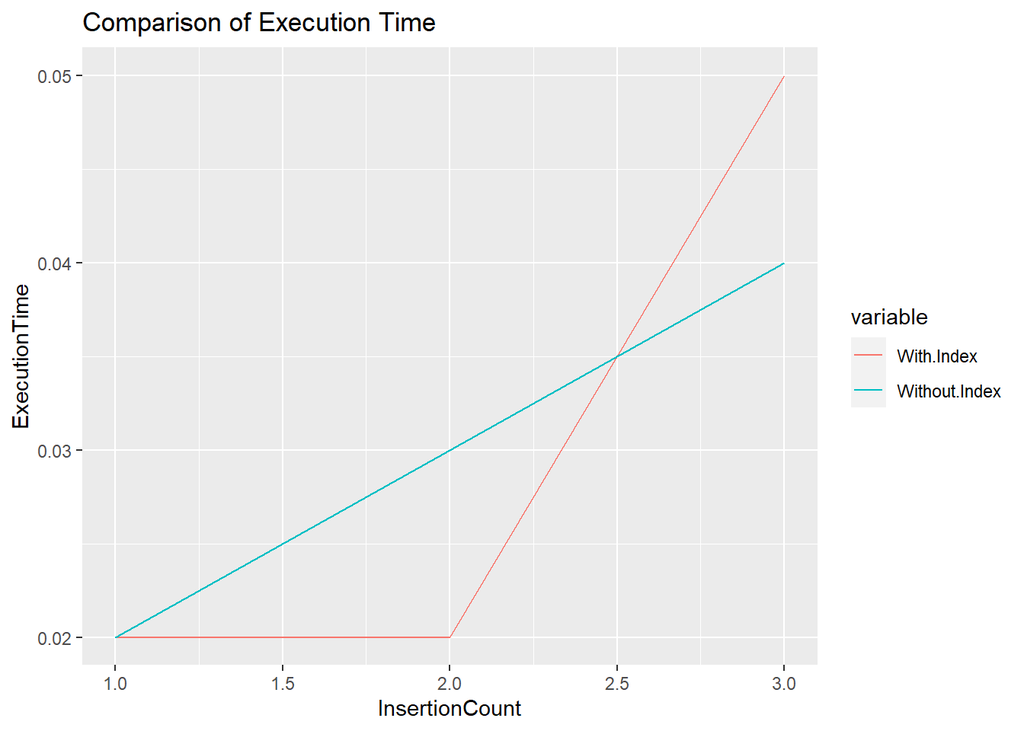

```r
end_time_1 <- Sys.time()

q3<-round(difftime(end_time_1, start_time_1, units = "sec"),2)









##Display
data <- data.frame(InsertionCount=c(1,2,3),
    With.Index=as.numeric(c(p1,p2,p3)) ,
    Without.Index=as.numeric(c(q1,q2,q3))
)

# LinePLot
library(reshape2)
test_data<-melt(data, id="InsertionCount")
colnames(test_data)<-c("InsertionCount","variable","ExecutionTime")
ggplot(data=test_data,aes(x=InsertionCount, y=ExecutionTime, colour=variable)) + geom_line()+ggtitle("Comparison of Execution Time")
```

```r
dbExecute(con,"delete from Episodes  where tconst='tt1111111'; ")
```

```
## [1] 1
```

```r
dbExecute(con,"delete from Episodes  where tconst='tt1111112'; ")
```

```
## [1] 1
```

```r
dbExecute(con,"delete from Episodes  where tconst='tt1111113'; ")
```

```
## [1] 1
```

```r
dbExecute(con,"delete from Episodes  where tconst='tt1111114';  ")
```

```
## [1] 1
```

```r
dbExecute(con,"delete from Episodes  where tconst='tt1111115';  ")
```

```
## [1] 1
```

```r
dbExecute(con,"delete from Episodes  where tconst='tt1111116';  ")
```

```
## [1] 1
```

```r
#dbGetQuery(con,"select * from Episodes where parentTconst='tt0048844' ")
```